# PYODBC (1)

#### In this project, I am going to use different SQL queries to gain information and insight about wine scoring data. This data was obtained from kaggle (https://www.kaggle.com/zynicide/wine-reviews). It contains information about reviews and scores made by some wine magazine (WineEnthusiast) for a wide range of wines in the world.

First, I am importing pyodbc to connect to MS SQL server in Jupyter notebook.

```python
import pyodbc
```

```python
import matplotlib.pyplot as plt
```

```python
import numpy as np
```

I am then loading the SQL extension by running the following magic SQL command.

```python
%load_ext sql
```

The following line establishes connection to the existing MS SQL server database.

```python
%sql mssql+pyodbc://@DESKTOP-M2MFJA5\SQLEXPRESS/wine?driver=SQL+SERVER
```

```
'Connected: @wine'
```

Let's first take a look at the top 5 rows of the datasets.

```python
%sql SELECT top 5 * from winemag_first150k
```

```
 * mssql+pyodbc://@DESKTOP-M2MFJA5\SQLEXPRESS/wine?driver=SQL SERVER
Done.
```

| Column_1 | country | description | designation | points | price | province | region_1 | region_2 | variety | winery |
| --- | --- | --- | --- | --- | --- | --- | --- | --- | --- | --- |
| 0 | US | This tremendous 100% varietal wine hails from Oakville and was aged over three years in oak. Juicy red-cherry fruit and a compelling hint of caramel greet the palate, framed by elegant, fine tannins a… | Martha's Vineyard | 96 | 235.0 | California | Napa Valley | Napa | Cabernet Sauvignon | Heitz |
| 1 | Spain | Ripe aromas of fig, blackberry and cassis are softened and sweetened by a slathering of oaky chocolate and vanilla. This is full, layered, intense and cushioned on the palate, with rich flavors of cho… | Carodorum Selección Especial Reserva | 96 | 110.0 | Northern Spain | Toro | None | Tinta de Toro | Bodega Carmen Rodríguez |
| 2 | US | Mac Watson honors the memory of a wine once made by his mother in this tremendously delicious, balanced and complex botrytised white. Dark gold in color, it layers toasted hazelnut, pear compote and o… | Special Selected Late Harvest | 96 | 90.0 | California | Knights Valley | Sonoma | Sauvignon Blanc | Macauley |
| 3 | US | This spent 20 months in 30% new French oak, and incorporates fruit from Ponzi's Aurora, Abetina and Madrona vineyards, among others. Aromatic, dense and toasty, it deftly blends aromas and flavors of … | Reserve | 96 | 65.0 | Oregon | Willamette Valley | Willamette Valley | Pinot Noir | Ponzi |
| 4 | France | This is the top wine from La Bégude, named after the highest point in the vineyard at 1200 feet. It has structure, density and considerable acidity that is still calming down. With 18 months in wood, … | La Brûlade | 95 | 66.0 | Provence | Bandol | None | Provence red blend | Domaine de la Bégude |

From this we can see that this dataset contains information about wines regarding the country of origin, description, winery, scored point, province, region and variety.

Let's take a look at the information schema table to get more in-depth information about the dataset.

```python
%sql SELECT * from INFORMATION_SCHEMA.COLUMNS
```

```
 * mssql+pyodbc://@DESKTOP-M2MFJA5\SQLEXPRESS/wine?driver=SQL SERVER
Done.
```

| TABLE_CATALOG | TABLE_SCHEMA | TABLE_NAME | COLUMN_NAME | ORDINAL_POSITION | COLUMN_DEFAULT | IS_NULLABLE | DATA_TYPE | CHARACTER_MAXIMUM_LENGTH | CHARACTER_OCTET_LENGTH | NUMERIC_PRECISION | NUMERIC_PRECISION_RADIX | NUMERIC_SCALE | DATETIME_PRECISION | CHARACTER_SET_CATALOG | CHARACTER_SET_SCHEMA | CHARACTER_SET_NAME | COLLATION_CATALOG | COLLATION_SCHEMA | COLLATION_NAME | DOMAIN_CATALOG | DOMAIN_SCHEMA | DOMAIN_NAME |
| --- | --- | --- | --- | --- | --- | --- | --- | --- | --- | --- | --- | --- | --- | --- | --- | --- | --- | --- | --- | --- | --- | --- |
| wine | dbo | winemag_first150k | Column_1 | 1 | None | YES | nvarchar | -1 | -1 | None | None | None | None | None | None | UNICODE | None | None | Korean_Wansung_CI_AS | None | None | None |
| wine | dbo | winemag_first150k | country | 2 | None | YES | nvarchar | -1 | -1 | None | None | None | None | None | None | UNICODE | None | None | Korean_Wansung_CI_AS | None | None | None |
| wine | dbo | winemag_first150k | description | 3 | None | YES | nvarchar | -1 | -1 | None | None | None | None | None | None | UNICODE | None | None | Korean_Wansung_CI_AS | None | None | None |
| wine | dbo | winemag_first150k | designation | 4 | None | YES | nvarchar | -1 | -1 | None | None | None | None | None | None | UNICODE | None | None | Korean_Wansung_CI_AS | None | None | None |
| wine | dbo | winemag_first150k | points | 5 | None | YES | int | None | None | 10 | 10 | 0 | None | None | None | None | None | None | None | None | None | None |
| wine | dbo | winemag_first150k | price | 6 | None | YES | float | None | None | 53 | 2 | None | None | None | None | None | None | None | None | None | None | None |
| wine | dbo | winemag_first150k | province | 7 | None | YES | nvarchar | -1 | -1 | None | None | None | None | None | None | UNICODE | None | None | Korean_Wansung_CI_AS | None | None | None |
| wine | dbo | winemag_first150k | region_1 | 8 | None | YES | nvarchar | -1 | -1 | None | None | None | None | None | None | UNICODE | None | None | Korean_Wansung_CI_AS | None | None | None |
| wine | dbo | winemag_first150k | region_2 | 9 | None | YES | nvarchar | -1 | -1 | None | None | None | None | None | None | UNICODE | None | None | Korean_Wansung_CI_AS | None | None | None |
| wine | dbo | winemag_first150k | variety | 10 | None | YES | nvarchar | -1 | -1 | None | None | None | None | None | None | UNICODE | None | None | Korean_Wansung_CI_AS | None | None | None |
| wine | dbo | winemag_first150k | winery | 11 | None | YES | nvarchar | -1 | -1 | None | None | None | None | None | None | UNICODE | None | None | Korean_Wansung_CI_AS | None | None | None |
| wine | dbo | winemag_130k_v2 | Column_1 | 1 | None | YES | nvarchar | -1 | -1 | None | None | None | None | None | None | UNICODE | None | None | Korean_Wansung_CI_AS | None | None | None |
| wine | dbo | winemag_130k_v2 | country | 2 | None | YES | nvarchar | -1 | -1 | None | None | None | None | None | None | UNICODE | None | None | Korean_Wansung_CI_AS | None | None | None |
| wine | dbo | winemag_130k_v2 | description | 3 | None | YES | nvarchar | -1 | -1 | None | None | None | None | None | None | UNICODE | None | None | Korean_Wansung_CI_AS | None | None | None |
| wine | dbo | winemag_130k_v2 | designation | 4 | None | YES | nvarchar | -1 | -1 | None | None | None | None | None | None | UNICODE | None | None | Korean_Wansung_CI_AS | None | None | None |
| wine | dbo | winemag_130k_v2 | points | 5 | None | YES | int | None | None | 10 | 10 | 0 | None | None | None | None | None | None | None | None | None | None |
| wine | dbo | winemag_130k_v2 | price | 6 | None | YES | nvarchar | -1 | -1 | None | None | None | None | None | None | UNICODE | None | None | Korean_Wansung_CI_AS | None | None | None |
| wine | dbo | winemag_130k_v2 | province | 7 | None | YES | nvarchar | -1 | -1 | None | None | None | None | None | None | UNICODE | None | None | Korean_Wansung_CI_AS | None | None | None |
| wine | dbo | winemag_130k_v2 | region_1 | 8 | None | YES | nvarchar | -1 | -1 | None | None | None | None | None | None | UNICODE | None | None | Korean_Wansung_CI_AS | None | None | None |
| wine | dbo | winemag_130k_v2 | region_2 | 9 | None | YES | nvarchar | -1 | -1 | None | None | None | None | None | None | UNICODE | None | None | Korean_Wansung_CI_AS | None | None | None |
| wine | dbo | winemag_130k_v2 | taster_name | 10 | None | YES | nvarchar | -1 | -1 | None | None | None | None | None | None | UNICODE | None | None | Korean_Wansung_CI_AS | None | None | None |
| wine | dbo | winemag_130k_v2 | taster_twitter_handle | 11 | None | YES | nvarchar | -1 | -1 | None | None | None | None | None | None | UNICODE | None | None | Korean_Wansung_CI_AS | None | None | None |
| wine | dbo | winemag_130k_v2 | title | 12 | None | YES | nvarchar | 150 | 300 | None | None | None | None | None | None | UNICODE | None | None | Korean_Wansung_CI_AS | None | None | None |
| wine | dbo | winemag_130k_v2 | variety | 13 | None | YES | nvarchar | -1 | -1 | None | None | None | None | None | None | UNICODE | None | None | Korean_Wansung_CI_AS | None | None | None |
| wine | dbo | winemag_130k_v2 | winery | 14 | None | YES | nvarchar | -1 | -1 | None | None | None | None | None | None | UNICODE | None | None | Korean_Wansung_CI_AS | None | None | None |

From this we can see that there are two tables in this dataset: (1) winemag_first150k and (2)winemag_130k_v2. I will use the first table only for this data analysis.

To see how many instances are 'empty' in each column in the original data table, I made the following SQL query. Basically I am assigning '1' to null values and '0' to non-null values and summing up the values across the rows. If the summed up value is 0 for a certain column, it means all rows in that specific column does NOT have any null values.

```python
%sql SELECT sum(case when country is null then 1 else 0 end) as country,sum(case when price is null then 1 else 0 end) as price,sum(case when province is null then 1 else 0 end) as province, sum(case when region_1 is null then 1 else 0 end) as region_1, sum(case when region_2 is null then 1 else 0 end) as region_2, sum(case when variety is null then 1 else 0 end) as variety, sum(case when winery is null then 1 else 0 end) as winery from winemag_first150k
```

```
 * mssql+pyodbc://@DESKTOP-M2MFJA5\SQLEXPRESS/wine?driver=SQL SERVER
Done.
```

| country | price | province | region_1 | region_2 | variety | winery |
| --- | --- | --- | --- | --- | --- | --- |
| 5 | 13695 | 5 | 25060 | 89977 | 0 | 0 |

From this we can see that there are some null values except for variety and winery columns.

To verify if this really had worked, let's run the following query for "winery" column to see if there are any 'null' values in the winery column.

According to the query above, we are supposed have "0" null values.

```python
%sql SELECT * from winemag_first150k WHERE winery is NULL
```

```
 * mssql+pyodbc://@DESKTOP-M2MFJA5\SQLEXPRESS/wine?driver=SQL SERVER
0 rows affected.
```

| Column_1 | country | description | designation | points | price | province | region_1 | region_2 | variety | winery |
| --- | --- | --- | --- | --- | --- | --- | --- | --- | --- | --- |

You can see that we did not get any result back, which indicates that the "null value summation" result is accurate.

Having confirmed this, let's look at the list of countries that had produced the wines for which this maganize reviewed. I am using "DISTINCT" to ignore any multiple occurences.

```python
%sql SELECT DISTINCT country from winemag_first150k WHERE country is NOT NULL ORDER BY country
```

```
 * mssql+pyodbc://@DESKTOP-M2MFJA5\SQLEXPRESS/wine?driver=SQL SERVER
Done.
```

| country |
| --- |
| Albania |
| Argentina |
| Australia |
| Austria |
| Bosnia and Herzegovina |
| Brazil |
| Bulgaria |
| Canada |
| Chile |
| China |
| Croatia |
| Cyprus |
| Czech Republic |
| Egypt |
| England |
| France |
| Georgia |
| Germany |
| Greece |
| Hungary |
| India |
| Israel |
| Italy |
| Japan |
| Lebanon |
| Lithuania |
| Luxembourg |
| Macedonia |
| Mexico |
| Moldova |
| Montenegro |
| Morocco |
| New Zealand |
| Portugal |
| Romania |
| Serbia |
| Slovakia |
| Slovenia |
| South Africa |
| South Korea |
| Spain |
| Switzerland |
| Tunisia |
| Turkey |
| Ukraine |
| Uruguay |
| US |
| US-France |

That is a long list to my surprise. OK. I got curious to see which country has the largest number of wineries and which country has the smallest number. This can be collected by running the following SQL query utilizing 'count' and 'group by'.

```python
%sql SELECT COUNT(winery) as number_of_wineries, country \
from winemag_first150k \
WHERE country IS NOT NULL \
GROUP BY country \
ORDER BY number_of_wineries DESC;
```

```
 * mssql+pyodbc://@DESKTOP-M2MFJA5\SQLEXPRESS/wine?driver=SQL SERVER
Done.
```

| number_of_wineries | country |
| --- | --- |
| 62397 | US |
| 23478 | Italy |
| 21098 | France |
| 8268 | Spain |
| 5816 | Chile |
| 5631 | Argentina |
| 5322 | Portugal |
| 4957 | Australia |
| 3320 | New Zealand |
| 3057 | Austria |
| 2452 | Germany |
| 2258 | South Africa |
| 884 | Greece |
| 630 | Israel |
| 231 | Hungary |
| 196 | Canada |
| 139 | Romania |
| 94 | Slovenia |
| 92 | Uruguay |
| 89 | Croatia |
| 77 | Bulgaria |
| 71 | Moldova |
| 63 | Mexico |
| 52 | Turkey |
| 43 | Georgia |
| 37 | Lebanon |
| 31 | Cyprus |
| 25 | Brazil |
| 16 | Macedonia |
| 14 | Serbia |
| 12 | Morocco |
| 9 | England |
| 9 | Luxembourg |
| 8 | Lithuania |
| 8 | India |
| 6 | Czech Republic |
| 5 | Ukraine |
| 4 | Bosnia and Herzegovina |
| 4 | South Korea |
| 4 | Switzerland |
| 3 | Slovakia |
| 3 | China |
| 3 | Egypt |
| 2 | Montenegro |
| 2 | Albania |
| 2 | Japan |
| 2 | Tunisia |
| 1 | US-France |

Acoording to this, the U.S has about ~62,000 wineries. I did not know South Korea would have 4 wineries that got reviewed by this magazine. :)

Let's save this result as a pandas data frame so that we can do some plotting ,etc.

```python
result=%sql SELECT COUNT(winery) as number_of_wineries, country \
from winemag_first150k \
WHERE country IS NOT NULL \
GROUP BY country \
ORDER BY number_of_wineries DESC;

df1=result.DataFrame()
```

```
 * mssql+pyodbc://@DESKTOP-M2MFJA5\SQLEXPRESS/wine?driver=SQL SERVER
Done.
```

I am checking if the saved dataframe "df1" would look the same as my returned SQL query result shown above.

```python
df1
```

|  | number_of_wineries | country |
| --- | --- | --- |
| 0 | 62397 | US |
| 1 | 23478 | Italy |
| 2 | 21098 | France |
| 3 | 8268 | Spain |
| 4 | 5816 | Chile |
| 5 | 5631 | Argentina |
| 6 | 5322 | Portugal |
| 7 | 4957 | Australia |
| 8 | 3320 | New Zealand |
| 9 | 3057 | Austria |
| 10 | 2452 | Germany |
| 11 | 2258 | South Africa |
| 12 | 884 | Greece |
| 13 | 630 | Israel |
| 14 | 231 | Hungary |
| 15 | 196 | Canada |
| 16 | 139 | Romania |
| 17 | 94 | Slovenia |
| 18 | 92 | Uruguay |
| 19 | 89 | Croatia |
| 20 | 77 | Bulgaria |
| 21 | 71 | Moldova |
| 22 | 63 | Mexico |
| 23 | 52 | Turkey |
| 24 | 43 | Georgia |
| 25 | 37 | Lebanon |
| 26 | 31 | Cyprus |
| 27 | 25 | Brazil |
| 28 | 16 | Macedonia |
| 29 | 14 | Serbia |
| 30 | 12 | Morocco |
| 31 | 9 | England |
| 32 | 9 | Luxembourg |
| 33 | 8 | Lithuania |
| 34 | 8 | India |
| 35 | 6 | Czech Republic |
| 36 | 5 | Ukraine |
| 37 | 4 | Bosnia and Herzegovina |
| 38 | 4 | South Korea |
| 39 | 4 | Switzerland |
| 40 | 3 | Slovakia |
| 41 | 3 | China |
| 42 | 3 | Egypt |
| 43 | 2 | Montenegro |
| 44 | 2 | Albania |
| 45 | 2 | Japan |
| 46 | 2 | Tunisia |
| 47 | 1 | US-France |

It looks the same, so we are good!

OK. Let's do some plotting then. This will visulaize the 'global wine population".

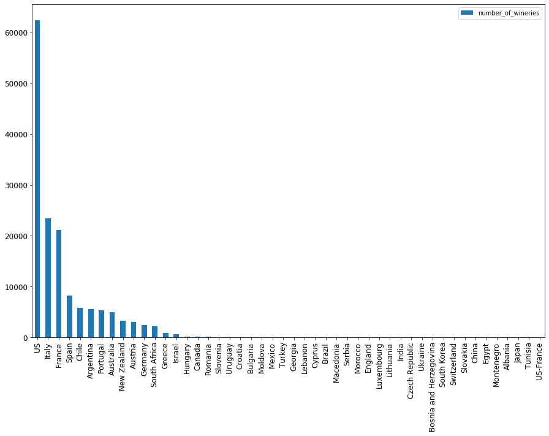

```python
labels=df1['country']

ax = df1[['number_of_wineries','country']].plot(kind='bar', figsize=(15, 10), legend=True, fontsize=12)
ax.set_xticklabels(labels)
plt.show()
```

Now let's focus only on those 'perfect wines'. By being 'perfect', I mean those that scored 100 in this wine review magaznie. I am excluding the instances where the country of origin is N/A, and grouping them by country, province,winery and variety.

I am also getting the average price of these perfect wines just to see how expensive they are.

```python
%sql SELECT COUNT(winery) as number_of_wines, avg(price) as average_price, winery, province, country, variety \
from winemag_first150k \
WHERE country IS NOT NULL \
AND points = 100 \
GROUP BY country,province,winery,variety \
ORDER BY average_price DESC;
```

```
 * mssql+pyodbc://@DESKTOP-M2MFJA5\SQLEXPRESS/wine?driver=SQL SERVER
Done.
```

| number_of_wines | average_price | winery | province | country | variety |
| --- | --- | --- | --- | --- | --- |
| 3 | 1400.0 | Krug | Champagne | France | Chardonnay |
| 1 | 848.0 | Château Haut-Brion | Bordeaux | France | Bordeaux-style White Blend |
| 3 | 460.0 | Tenuta dell'Ornellaia | Tuscany | Italy | Merlot |
| 3 | 300.0 | Chambers Rosewood Vineyards | Victoria | Australia | Muscat |
| 2 | 245.0 | Sloan | California | US | Cabernet Blend |
| 1 | 215.0 | Shafer | California | US | Cabernet Sauvignon |
| 2 | 210.0 | Avignonesi | Tuscany | Italy | Prugnolo Gentile |
| 2 | 200.0 | Cardinale | California | US | Cabernet Sauvignon |
| 2 | 195.0 | Giovanni Chiappini | Tuscany | Italy | Red Blend |
| 2 | 100.0 | Williams Selyem | California | US | Pinot Noir |
| 3 | 65.0 | Cayuse | Oregon | US | Syrah |

We can see that there are not many wines that scored 100 and the average price varies a lot too. For example, the average price of the 3 wines that had been produced by Krug, the french winery is about 20 times more expensive than the Oregon ones (average price: $65)

I am currently living in Oregon so I am proud of this result :) But, let's take a deeper look at these perfect oregon wines. Going back to our orignial data table for this.

```python
%sql select * from winemag_first150k where points=100 AND province='Oregon'
```

```
 * mssql+pyodbc://@DESKTOP-M2MFJA5\SQLEXPRESS/wine?driver=SQL SERVER
Done.
```

| Column_1 | country | description | designation | points | price | province | region_1 | region_2 | variety | winery |
| --- | --- | --- | --- | --- | --- | --- | --- | --- | --- | --- |
| 19354 | US | In a stunning lineup of Cayuse Syrahs, the En Chamberlin wins by a nose. It's smooth and silky, with a tongue-bending blend of flavors that include blood and iron, umami and salt, at first overtaking … | En Chamberlin Vineyard | 100 | 65.0 | Oregon | Walla Walla Valley (OR) | Oregon Other | Syrah | Cayuse |
| 84034 | US | In a stunning lineup of Cayuse Syrahs, the En Chamberlin wins by a nose. It's smooth and silky, with a tongue-bending blend of flavors that include blood and iron, umami and salt, at first overtaking … | En Chamberlin Vineyard | 100 | 65.0 | Oregon | Walla Walla Valley (OR) | Oregon Other | Syrah | Cayuse |
| 119194 | US | In a stunning lineup of Cayuse Syrahs, the En Chamberlin wins by a nose. It's smooth and silky, with a tongue-bending blend of flavors that include blood and iron, umami and salt, at first overtaking … | En Chamberlin Vineyard | 100 | 65.0 | Oregon | Walla Walla Valley (OR) | Oregon Other | Syrah | Cayuse |

Interestingly, all of these wines came from one single winery "Cayuse". I am marking my map now :)

OK. Let's go back to our original data table and summarize some information with respect to scored points. I am choosing "number of wines" and "average price" as the features to look for. For this my SQL query contains "avg(price)" and "group by points".

```python
%sql SELECT count(winery) as number_of_wines, round(avg(price),2) as average_price, points from winemag_first150k group by points ORDER BY points DESC
```

```
 * mssql+pyodbc://@DESKTOP-M2MFJA5\SQLEXPRESS/wine?driver=SQL SERVER
Done.
```

| number_of_wines | average_price | points |
| --- | --- | --- |
| 24 | 401.58 | 100 |
| 50 | 289.52 | 99 |
| 131 | 232.13 | 98 |
| 365 | 178.0 | 97 |
| 695 | 132.35 | 96 |
| 1716 | 108.93 | 95 |
| 3462 | 81.94 | 94 |
| 6017 | 66.43 | 93 |
| 9241 | 52.3 | 92 |
| 10536 | 43.76 | 91 |
| 15973 | 37.36 | 90 |
| 12921 | 32.54 | 89 |
| 17871 | 27.83 | 88 |
| 20747 | 24.59 | 87 |
| 15573 | 21.82 | 86 |
| 12411 | 20.06 | 85 |
| 10708 | 19.37 | 84 |
| 6048 | 18.01 | 83 |
| 4041 | 19.17 | 82 |
| 1502 | 17.67 | 81 |
| 898 | 17.22 | 80 |

Visualizing this will help us a lot. Let's create a pandas dataframe named "df2" out of this and visualize how this query result looks

```python
result2=%sql SELECT count(winery) as number_of_wines, round(avg(price),2) as average_price, points from winemag_first150k group by points ORDER BY points DESC
df2=result2.DataFrame()
```

```
 * mssql+pyodbc://@DESKTOP-M2MFJA5\SQLEXPRESS/wine?driver=SQL SERVER
Done.
```

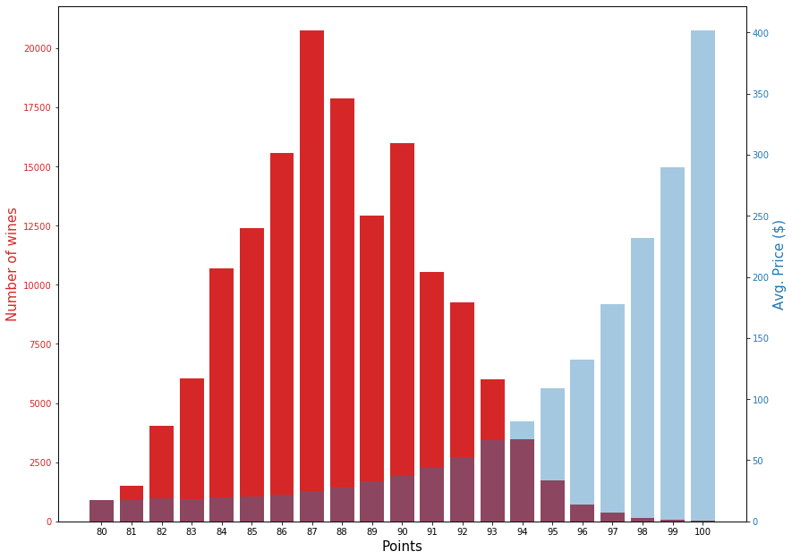

```python
labels=df2['points']
N=len(df2)

ind=np.arange(N)

price=df2['average_price']

fig, ax1 = plt.subplots()
color='tab:red'

ax1.set_xlabel('Points',fontsize=15)
ax1.set_ylabel('Number of wines', color=color,fontsize=15)
ax1.bar(labels, df2['number_of_wines'], color=color)
ax1.tick_params(axis='y', labelcolor=color)

ax2 = ax1.twinx()
color = 'tab:blue'
ax2.set_ylabel('Avg. Price ($)', color=color,fontsize=15)  # we already handled the x-label with ax1
ax2.bar(labels, price, alpha=0.4, color=color)
ax2.tick_params(axis='y', labelcolor=color)

fig.tight_layout()

plt.xticks(labels)
plt.gcf().set_size_inches(15, 10)
plt.show()
```

The plot above is the visualized analysis on # of wines and average prices for each scored point.

We can clearly see that the population follows some bell-shaped normal distribution as expected. Overall we don't expect there will be a ton of 'perfect wines' and also a ton of 'low quality wines'.

Also, the average price becomes more expensive as the points go up. This makes sense as you do would not pay more for lower quality ones :)

Hope you enjoyed my quick SQL analysis!